# RPeer-graded Assignment: Prediction Assignment Writeup

Veronica S.Jamilat

June 4, 2017

## Introduction

This report is prepared as one of the requirement in Practical Machine Learning online course by Johns Hopkins University. The basic goal of this assignment is to predict the manner of the subject (6 participants) performed some exercise. For this assignment, in order to predict the manner of the subject did the exercise decision tree and random forest method will be performed to determine the best prediction. The best prediction is determined by the highest accuracy.

## Background

Using devices such as Jawbone Up, Nike FuelBand, and Fitbit it is now possible to collect a large amount of data about personal activity relatively inexpensively. These type of devices are part of the quantified self movement. A group of enthusiasts who take measurements about themselves regularly to improve their health, to find patterns in their behavior, or because they are tech geeks. One thing that people regularly do is quantify how much of a particular activity they do, but they rarely quantify how well they do it. In this project, your goal will be to use data from accelerometers on the belt, forearm, arm, and dumbell of 6 participants. They were asked to perform barbell lifts correctly and incorrectly in 5 different ways. More information is available from the website [**here**](http://groupware.les.inf.puc-rio.br/har)

## Data

The training data for this project are available [**here**](https://d396qusza40orc.cloudfront.net/predmachlearn/pml-training.csv)

The test data are available [**here**](https://d396qusza40orc.cloudfront.net/predmachlearn/pml-testing.csv)

The data for this project come from [**this**](http://groupware.les.inf.puc-rio.br/har) source.

## Pre-processing

This segment includes packages required and uploading data into r.

Packages needed to perform bagging, random forest and boosting are as follows:

```r
ECHO=TRUE

library(e1071)
library(caret)
```

```r
library(rpart)
library(rpart.plot)
library(rattle)
library(randomForest)
library(corrplot)


#locate downloaded dataset
testing<-read.csv(file="pml-testing.csv",head=TRUE,sep=",")
training<-read.csv(file="pml-training.csv",head=TRUE,sep=",")

## Data processing
# create a partition using caret with the training dataset on 70,30 ratio
inTrain  <- createDataPartition(training$classe, p=0.7, list=FALSE)
TrainSet <- training[inTrain, ]
TestSet  <- training[-inTrain, ]
dim(TrainSet)
```

```
## [1] 13737   160
```

```r
dim(TestSet)
```

```
## [1] 5885  160
```

```r
# remove variables with Nearly Zero Variance
n0var <- nearZeroVar(TrainSet)
TrainSet <- TrainSet[, -n0var]
TestSet  <- TestSet[, -n0var]
dim(TrainSet)
```

```
## [1] 13737   100
```

```r
dim(TestSet)
```

```
## [1] 5885  100
```

```r
# remove variables that are mostly NA
AllNA <- sapply(TrainSet, function(x) mean(is.na(x))) > 0.95
TrainSet <- TrainSet[, AllNA==FALSE]
TestSet <- TestSet[, AllNA==FALSE]
dim(TrainSet)
```

```
## [1] 13737    59
```

```r
dim(TestSet)
```

```
## [1] 5885   59
```

```r
# remove identification only variables (columns 1 to 5)
TrainSet <- TrainSet[, -(1:5)]
TestSet  <- TestSet[, -(1:5)]
dim(TrainSet)
```

```
## [1] 13737    54
```

```r
dim(TestSet)
```

```
## [1] 5885   54
```

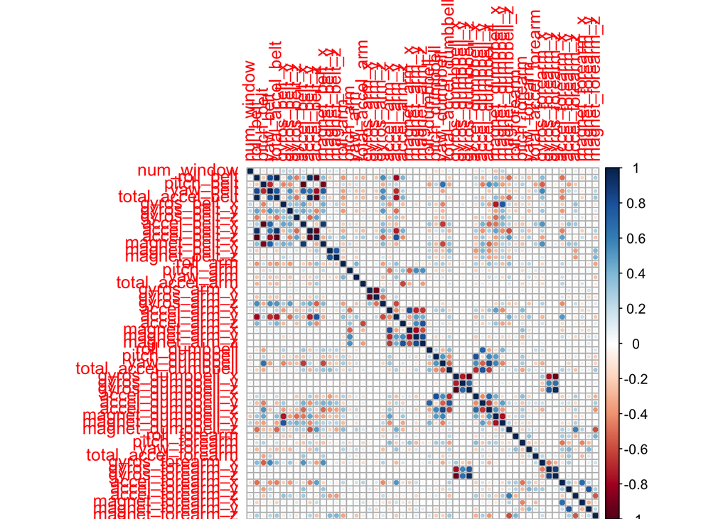

```r
#check correlation among variables
M <- cor(TrainSet[, -54])
corrplot(M, method="circle")
```

```r
#1.random forest method
# model fit
set.seed(3408)
controlRF <- trainControl(method="cv", number=3, verboseIter=FALSE)
modFitRandForest <- train(classe ~ ., data=TrainSet, method="rf",
                          trControl=controlRF)
modFitRandForest$finalModel
```

```
##
## Call:
##  randomForest(x = x, y = y, mtry = param$mtry)
##                Type of random forest: classification
##                      Number of trees: 500
## No. of variables tried at each split: 27
##
##         OOB estimate of  error rate: 0.23%
## Confusion matrix:
##      A    B    C    D    E  class.error
## A 3904    1    0    0    1 0.0005120328
## B    7 2648    3    0    0 0.0037622272
## C    0    5 2391    0    0 0.0020868114
## D    0    1   10 2241    0 0.0048845471
## E    0    0    0    3 2522 0.0011881188
```

```r
# prediction on Test dataset
predictRandForest <- predict(modFitRandForest, newdata=TestSet)
confMatRandForest <- confusionMatrix(predictRandForest, TestSet$classe)
confMatRandForest
```

```
## Confusion Matrix and Statistics
##
##           Reference
## Prediction    A    B    C    D    E
##          A 1674    1    0    0    0
##          B    0 1137    0    0    2
##          C    0    0 1026    2    0
##          D    0    1    0  961    2
##          E    0    0    0    1 1078
##
## Overall Statistics
##
##                Accuracy : 0.9985
##                  95% CI : (0.9971, 0.9993)
##     No Information Rate : 0.2845
##     P-Value [Acc > NIR] : < 2.2e-16
##
##                   Kappa : 0.9981
##  Mcnemar's Test P-Value : NA
##
## Statistics by Class:
##
##                      Class: A Class: B Class: C Class: D Class: E
## Sensitivity            1.0000   0.9982   1.0000   0.9969   0.9963
## Specificity            0.9998   0.9996   0.9996   0.9994   0.9998
## Pos Pred Value         0.9994   0.9982   0.9981   0.9969   0.9991
## Neg Pred Value         1.0000   0.9996   1.0000   0.9994   0.9992
## Prevalence             0.2845   0.1935   0.1743   0.1638   0.1839
## Detection Rate         0.2845   0.1932   0.1743   0.1633   0.1832
## Detection Prevalence   0.2846   0.1935   0.1747   0.1638   0.1833
## Balanced Accuracy      0.9999   0.9989   0.9998   0.9981   0.9980
```

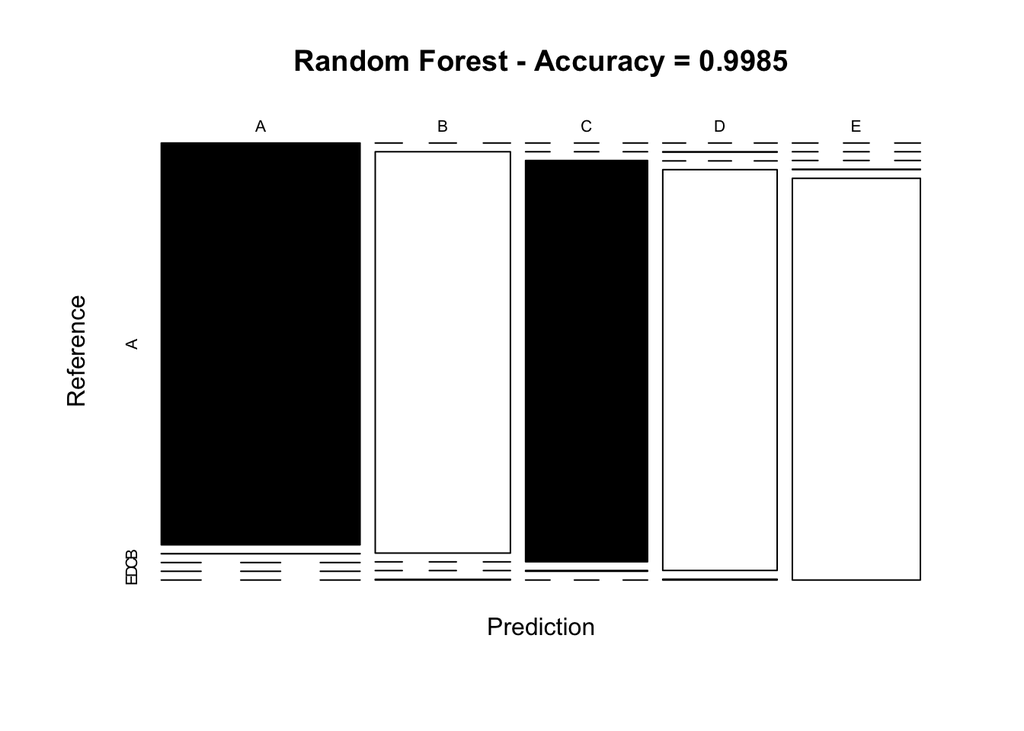

```r
# plot matrix results
plot(confMatRandForest$table, col = confMatRandForest$byClass,
     main = paste("Random Forest - Accuracy =",
                  round(confMatRandForest$overall['Accuracy'], 4)))
```

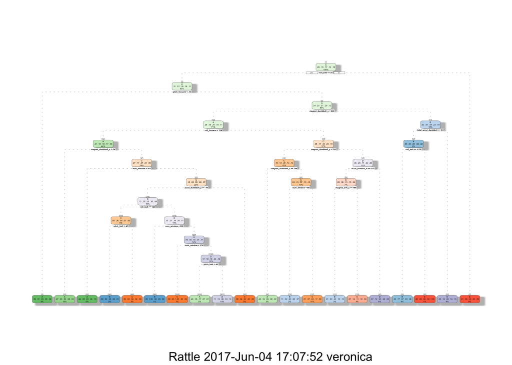

```r
#2.Decision tree
# model fit
set.seed(3408)
modFitDecTree <- rpart(classe ~ ., data=TrainSet, method="class")
fancyRpartPlot(modFitDecTree)
```

```r
# prediction on Test dataset
predictDecTree <- predict(modFitDecTree, newdata=TestSet, type="class")
confMatDecTree <- confusionMatrix(predictDecTree, TestSet$classe)
confMatDecTree
```

```
## Confusion Matrix and Statistics
##
##           Reference
## Prediction    A    B    C    D    E
##          A 1531  272   53  135  106
##          B   32  637   70   37   83
##          C    7   62  814  142   67
##          D   80  127   64  607  117
##          E   24   41   25   43  709
##
## Overall Statistics
##
##                Accuracy : 0.7303
##                  95% CI : (0.7188, 0.7416)
##     No Information Rate : 0.2845
##     P-Value [Acc > NIR] : < 2.2e-16
##
##                   Kappa : 0.6561
##  Mcnemar's Test P-Value : < 2.2e-16
##
## Statistics by Class:
##
##                      Class: A Class: B Class: C Class: D Class: E
## Sensitivity            0.9146   0.5593   0.7934   0.6297   0.6553
## Specificity            0.8656   0.9532   0.9428   0.9212   0.9723
## Pos Pred Value         0.7301   0.7416   0.7454   0.6101   0.8420
## Neg Pred Value         0.9622   0.9001   0.9558   0.9270   0.9260
## Prevalence             0.2845   0.1935   0.1743   0.1638   0.1839
## Detection Rate         0.2602   0.1082   0.1383   0.1031   0.1205
## Detection Prevalence   0.3563   0.1460   0.1856   0.1691   0.1431
## Balanced Accuracy      0.8901   0.7562   0.8681   0.7754   0.8138
```

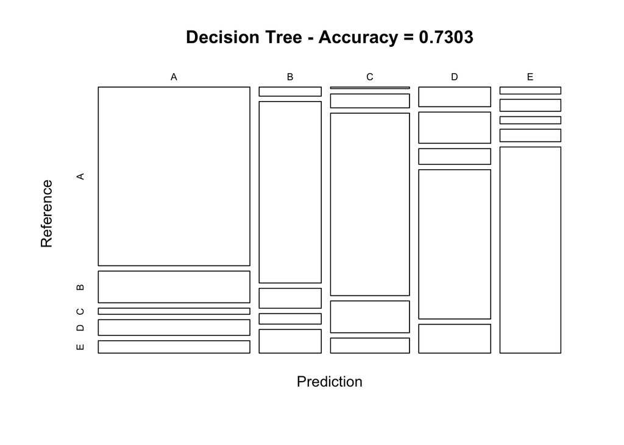

```r
#plot matrix results
plot(confMatDecTree$table, col = confMatDecTree$byClass,
     main = paste("Decision Tree - Accuracy =",
                  round(confMatDecTree$overall['Accuracy'], 4)))
```

```r
#3. Applying the selected Model to the Test Data (Random Forest is selected because of higher accuracy)
predictTEST <- predict(modFitRandForest, newdata=testing)
predictTEST
```

```
##  [1] B A B A A E D B A A B C B A E E A B B B
## Levels: A B C D E
```